# Model Stacking: SuperLearner

## Setup

```r
library(tidyverse)
library(tidylog, warn.conflicts = FALSE) # load this last!

library(skimr)
library(patchwork)
library(gt)
library(janitor) # data cleaning

library(tidymodels)
library(stacks)
# tidymodels
# library(rsample)
# library(recipes)
# library(parsnip)
# library(tune)
# library(dials)
# library(workflows)
# library(yardstick)
```

Speed up computation with parrallel processing (optional)

```r
library(doParallel)
all_cores <- parallel::detectCores(logical = FALSE)
registerDoParallel(cores = all_cores)
```

```r
# set the random seed so we can reproduce any simulated results.
set.seed(1004)
```

# 1 Background

SuperLearner is an algorithm that uses cross-validation to estimate the performance of multiple machine learning models, or the same model with different settings. It then creates an optimal weighted average of those models, aka an “ensemble”, using the test data performance. This approach has been proven to be asymptotically as accurate as the best possible prediction algorithm that is tested.

(We are oversimplifying this in the interest of brevity. Please see the references for more detailed information, especially “SuperLearner in Prediction”.)

```r
library(SuperLearner) # remotes::install_github("ecpolley/SuperLearner")
library(RhpcBLASctl)
```

# 2 Setup dataset

We will be using the “Boston” dataset which is available from the “MASS” package.

```r
############################
# Setup example dataset.

# Load a dataset from the MASS package.
data(Boston, package = "MASS")

# Review info on the Boston dataset.
# ?MASS::Boston

# Check for any missing data - looks like we don't have any.
colSums(is.na(Boston))
```

```
-->     crim      zn   indus    chas     nox      rm     age     dis     rad     tax ptratio   black   lstat    medv
-->        0       0       0       0       0       0       0       0       0       0       0       0       0       0
```

```r
# Extract our outcome variable from the dataframe.
outcome = Boston$medv

# Create a dataframe to contain our explanatory variables.
data = subset(Boston, select = -medv)

# Check structure of our dataframe.
str(data)
```

```
-->  'data.frame':  506 obs. of  13 variables:
-->   $ crim   : num  0.00632 0.02731 0.02729 0.03237 0.06905 ...
-->   $ zn     : num  18 0 0 0 0 0 12.5 12.5 12.5 12.5 ...
-->   $ indus  : num  2.31 7.07 7.07 2.18 2.18 2.18 7.87 7.87 7.87 7.87 ...
-->   $ chas   : int  0 0 0 0 0 0 0 0 0 0 ...
-->   $ nox    : num  0.538 0.469 0.469 0.458 0.458 0.458 0.524 0.524 0.524 0.524 ...
-->   $ rm     : num  6.58 6.42 7.18 7 7.15 ...
-->   $ age    : num  65.2 78.9 61.1 45.8 54.2 58.7 66.6 96.1 100 85.9 ...
-->   $ dis    : num  4.09 4.97 4.97 6.06 6.06 ...
-->   $ rad    : int  1 2 2 3 3 3 5 5 5 5 ...
-->   $ tax    : num  296 242 242 222 222 222 311 311 311 311 ...
-->   $ ptratio: num  15.3 17.8 17.8 18.7 18.7 18.7 15.2 15.2 15.2 15.2 ...
-->   $ black  : num  397 397 393 395 397 ...
-->   $ lstat  : num  4.98 9.14 4.03 2.94 5.33 ...
```

```r
# If we had factor variables we would use model.matrix() to convert to numerics.

# Review our dimensions.
dim(data)
```

```
-->  [1] 506  13
```

```r
# Set a seed for reproducibility in this random sampling.
set.seed(1)

# Reduce to a dataset of 150 observations to speed up model fitting.
train_obs = sample(nrow(data), 150)

# X is our training sample.
x_train = data[train_obs, ]

# Create a holdout set for evaluating model performance.
# Note: cross-validation is even better than a single holdout sample.
x_holdout = data[-train_obs, ]

# Create a binary outcome variable: towns in which median home value is > 22,000.
outcome_bin = as.numeric(outcome > 22)

y_train = outcome_bin[train_obs]
y_holdout = outcome_bin[-train_obs]

# Review the outcome variable distribution.
table(y_train, useNA = "ifany")
```

```
-->  y_train
-->   0  1
-->  92 58
```

# 3 Review available models

```r
# Review available models.
SuperLearner::listWrappers()
```

```
-->   [1] "SL.bartMachine"      "SL.bayesglm"         "SL.biglasso"         "SL.caret"            "SL.caret.rpart"      "SL.cforest"          "SL.earth"            "SL.extraTrees"       "SL.gam"              "SL.gbm"              "SL.glm"              "SL.glm.interaction"  "SL.glmnet"           "SL.…
-->  [19] "SL.leekasso"         "SL.lm"               "SL.loess"            "SL.logreg"           "SL.mean"             "SL.nnet"             "SL.nnls"             "SL.polymars"         "SL.qda"              "SL.randomForest"     "SL.ranger"           "SL.ridge"            "SL.rpart"            "SL.…
-->  [37] "SL.step.interaction" "SL.stepAIC"          "SL.svm"              "SL.template"         "SL.xgboost"
-->  [1] "All"
-->  [1] "screen.corP"           "screen.corRank"        "screen.glmnet"         "screen.randomForest"   "screen.SIS"            "screen.template"       "screen.ttest"          "write.screen.template"
```

```r
# Peek at code for a model.
SL.glmnet
```

```
-->  function (Y, X, newX, family, obsWeights, id, alpha = 1, nfolds = 10,
-->      nlambda = 100, useMin = TRUE, loss = "deviance", ...)
-->  {
-->      .SL.require("glmnet")
-->      if (!is.matrix(X)) {
-->          X <- model.matrix(~-1 + ., X)
-->          newX <- model.matrix(~-1 + ., newX)
-->      }
-->      fitCV <- glmnet::cv.glmnet(x = X, y = Y, weights = obsWeights,
-->          lambda = NULL, type.measure = loss, nfolds = nfolds,
-->          family = family$family, alpha = alpha, nlambda = nlambda,
-->          ...)
-->      pred <- predict(fitCV, newx = newX, type = "response", s = ifelse(useMin,
-->          "lambda.min", "lambda.1se"))
-->      fit <- list(object = fitCV, useMin = useMin)
-->      class(fit) <- "SL.glmnet"
-->      out <- list(pred = pred, fit = fit)
-->      return(out)
-->  }
-->  <bytecode: 0x000000003fa67530>
-->  <environment: namespace:SuperLearner>
```

For maximum accuracy one might try at least the following models: glmnet, randomForest, XGBoost, SVM, and bartMachine. These should ideally be tested with multiple hyperparameter settings for each algorithm.

# 4 Fit individual models

Let’s fit 2 separate models: lasso (sparse, penalized OLS) and random forest. We specify family = binomial() because we are predicting a binary outcome, aka classification. With a continuous outcome we would specify family = gaussian().

```r
# Set the seed for reproducibility.
set.seed(1)

# Fit lasso model.
sl_lasso = SuperLearner(Y = y_train, X = x_train, family = binomial(),
                        SL.library = "SL.glmnet")
sl_lasso
```

```
-->
-->  Call:  SuperLearner(Y = y_train, X = x_train, family = binomial(), SL.library = "SL.glmnet")
-->
-->
-->                  Risk Coef
-->  SL.glmnet_All 0.0848    1
```

```r
# Review the elements in the SuperLearner object.
names(sl_lasso)
```

```
-->   [1] "call"              "libraryNames"      "SL.library"        "SL.predict"        "coef"              "library.predict"   "Z"                 "cvRisk"            "family"            "fitLibrary"        "cvFitLibrary"      "varNames"          "validRows"         "method"            "whichScre…
-->  [20] "metaOptimizer"     "env"               "times"
```

```r
# Here is the risk of the best model (discrete SuperLearner winner).
sl_lasso$cvRisk[which.min(sl_lasso$cvRisk)]
```

```
-->  SL.glmnet_All
-->         0.0848
```

```r
# Here is the raw glmnet result object:
str(sl_lasso$fitLibrary$SL.glmnet_All$object, max.level = 1)
```

```
-->  List of 12
-->   $ lambda    : num [1:90] 0.317 0.289 0.263 0.24 0.218 ...
-->   $ cvm       : num [1:90] 1.34 1.28 1.21 1.16 1.1 ...
-->   $ cvsd      : num [1:90] 0.0359 0.033 0.0304 0.0292 0.0291 ...
-->   $ cvup      : num [1:90] 1.38 1.31 1.24 1.18 1.13 ...
-->   $ cvlo      : num [1:90] 1.31 1.24 1.18 1.13 1.08 ...
-->   $ nzero     : Named int [1:90] 0 1 1 1 1 1 2 2 2 2 ...
-->    ..- attr(*, "names")= chr [1:90] "s0" "s1" "s2" "s3" ...
-->   $ call      : language glmnet::cv.glmnet(x = X, y = Y, weights = obsWeights, lambda = NULL, type.measure = loss, nfolds = nfolds, family| __truncated__
-->   $ name      : Named chr "Binomial Deviance"
-->    ..- attr(*, "names")= chr "deviance"
-->   $ glmnet.fit:List of 13
-->    ..- attr(*, "class")= chr [1:2] "lognet" "glmnet"
-->   $ lambda.min: num 0.0161
-->   $ lambda.1se: num 0.0652
-->   $ index     : int [1:2, 1] 33 18
-->    ..- attr(*, "dimnames")=List of 2
-->   - attr(*, "class")= chr "cv.glmnet"
```

```r
# Fit random forest.
sl_rf = SuperLearner(Y = y_train, X = x_train, family = binomial(),
                     SL.library = "SL.ranger")
sl_rf
```

```
-->
-->  Call:  SuperLearner(Y = y_train, X = x_train, family = binomial(), SL.library = "SL.ranger")
-->
-->
-->                  Risk Coef
-->  SL.ranger_All 0.0773    1
```

Risk is a measure of model accuracy or performance. We want our models to minimize the estimated risk, which means the model is making the fewest mistakes in its prediction. It’s basically the mean-squared error in a regression model, but you can customize it if you want.

SuperLearner is using cross-validation to estimate the risk on future data. By default it uses 10 folds; use the cvControl argument to customize.

The coefficient column tells us the weight or importance of each individual learner in the overall ensemble. By default the weights are always greater than or equal to 0 and sum to 1. In this case we only have one algorithm so the coefficient has to be 1. If a coefficient is 0 it means that the algorithm isn’t being used in the SuperLearner ensemble.

# 5 Fit multiple models

Instead of fitting the models separately and looking at the performance (lowest risk), we can fit them simultaneously. SuperLearner will then tell us which one is best (discrete winner) and also create a weighted average of multiple models.

We include the mean of Y (“SL.mean”) as a benchmark algorithm. It is a very simple prediction so the more complex algorithms should do better than the sample mean. We hope to see that it isn’t the best single algorithm (discrete winner) and has a low weight in the weighted-average ensemble. If it is the best algorithm something has likely gone wrong.

```r
set.seed(1)
sl = SuperLearner(Y = y_train, X = x_train, family = binomial(),
  SL.library = c("SL.mean", "SL.glmnet", "SL.ranger"))
sl
```

```
-->
-->  Call:  SuperLearner(Y = y_train, X = x_train, family = binomial(), SL.library = c("SL.mean", "SL.glmnet", "SL.ranger"))
-->
-->
-->                  Risk   Coef
-->  SL.mean_All   0.2377 0.0000
-->  SL.glmnet_All 0.0885 0.0221
-->  SL.ranger_All 0.0705 0.9779
```

```r
# Review how long it took to run the SuperLearner:
sl$times$everything
```

```
-->     user  system elapsed
-->     3.49    0.09    3.41
```

Again, the coefficient is how much weight SuperLearner puts on that model in the weighted-average. So if coefficient = 0 it means that model is not used at all. Here we see that random forest is given the most weight, following by lasso.

So we have an automatic ensemble of multiple learners based on the cross-validated performance of those learners, nice!

# 6 Predict on new data

Now that we have an ensemble let’s predict back on our holdout dataset and review the results.

```r
# Predict back on the holdout dataset.
# onlySL is set to TRUE so we don't fit algorithms that had weight = 0, saving computation.
pred = predict(sl, x_holdout, onlySL = TRUE)

# Check the structure of this prediction object.
str(pred)
```

```
-->  List of 2
-->   $ pred           : num [1:356, 1] 0.577 0.891 0.939 0.943 0.853 ...
-->   $ library.predict: num [1:356, 1:3] 0 0 0 0 0 0 0 0 0 0 ...
```

```r
# Review the columns of $library.predict.
summary(pred$library.predict)
```

```
-->         V1          V2              V3
-->   Min.   :0   Min.   :0.000   Min.   :0.000
-->   1st Qu.:0   1st Qu.:0.027   1st Qu.:0.048
-->   Median :0   Median :0.310   Median :0.306
-->   Mean   :0   Mean   :0.404   Mean   :0.412
-->   3rd Qu.:0   3rd Qu.:0.782   3rd Qu.:0.818
-->   Max.   :0   Max.   :0.998   Max.   :0.998
```

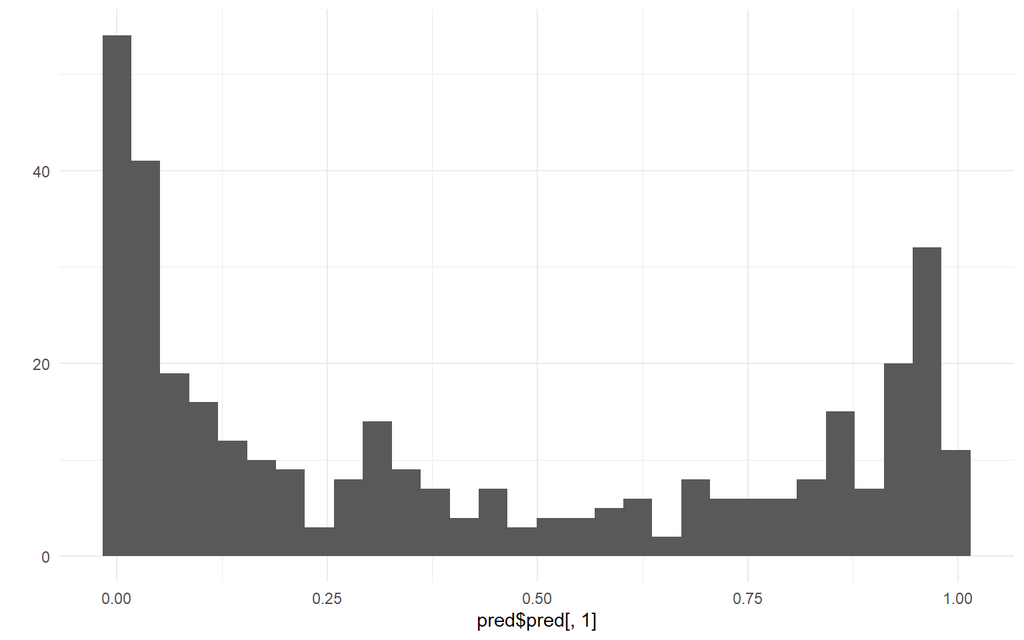

```r
# Histogram of our predicted values.
library(ggplot2)
qplot(pred$pred[, 1]) + theme_minimal()
```

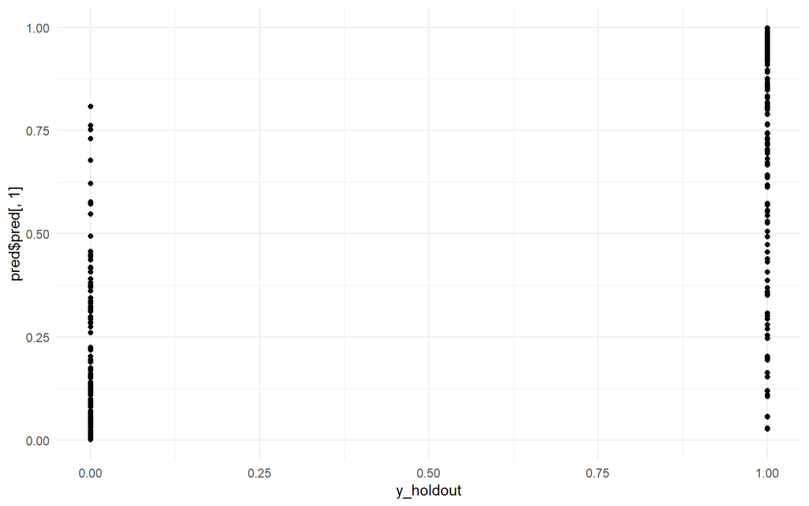

```r
# Scatterplot of original values (0, 1) and predicted values.
# Ideally we would use jitter or slight transparency to deal with overlap.
qplot(y_holdout, pred$pred[, 1]) + theme_minimal()
```

```r
# Review AUC - Area Under Curve
pred_rocr = ROCR::prediction(pred$pred, y_holdout)
auc = ROCR::performance(pred_rocr, measure = "auc", x.measure = "cutoff")@y.values[[1]]
auc
```

```
-->  [1] 0.944
```

# 7 Fit ensemble with external cross-validation

What we don’t have yet is an estimate of the performance of the ensemble itself. Right now we are just hopeful that the ensemble weights are successful in improving over the best single algorithm.

In order to estimate the performance of the SuperLearner ensemble we need an “external” layer of cross-validation, also called **nested cross-validation**. We generate a separate holdout sample that we don’t use to fit the SuperLearner, which allows it to be a good estimate of the SuperLearner’s performance on unseen data. Typically we would run 10 or 20-fold external cross-validation, but even 5-fold is reasonable.

Another nice result is that we get standard errors on the performance of the individual algorithms and can compare them to the SuperLearner.

```r
set.seed(1)

# Don't have timing info for the CV.SuperLearner unfortunately.
# So we need to time it manually.

system.time({
  # This will take about 2x as long as the previous SuperLearner.
  cv_sl = CV.SuperLearner(Y = y_train, X = x_train, family = binomial(),
                          # For a real analysis we would use V = 10.
                          V = 3,
                          SL.library = c("SL.mean", "SL.glmnet", "SL.ranger"))
})
```

```
-->     user  system elapsed
-->    14.21    0.23   14.27
```

```r
# We run summary on the cv_sl object rather than simply printing the object.
summary(cv_sl)
```

```
-->
-->  Call:  CV.SuperLearner(Y = y_train, X = x_train, V = 3, family = binomial(), SL.library = c("SL.mean", "SL.glmnet", "SL.ranger"))
-->
-->  Risk is based on: Mean Squared Error
-->
-->  All risk estimates are based on V =  3
-->
-->       Algorithm   Ave    se   Min   Max
-->   Super Learner 0.074 0.011 0.065 0.084
-->     Discrete SL 0.078 0.011 0.067 0.087
-->     SL.mean_All 0.251 0.010 0.229 0.290
-->   SL.glmnet_All 0.082 0.015 0.073 0.096
-->   SL.ranger_All 0.078 0.011 0.067 0.087
```

```r
# Review the distribution of the best single learner as external CV folds.
table(simplify2array(cv_sl$whichDiscreteSL))
```

```
-->
-->  SL.ranger_All
-->              3
```

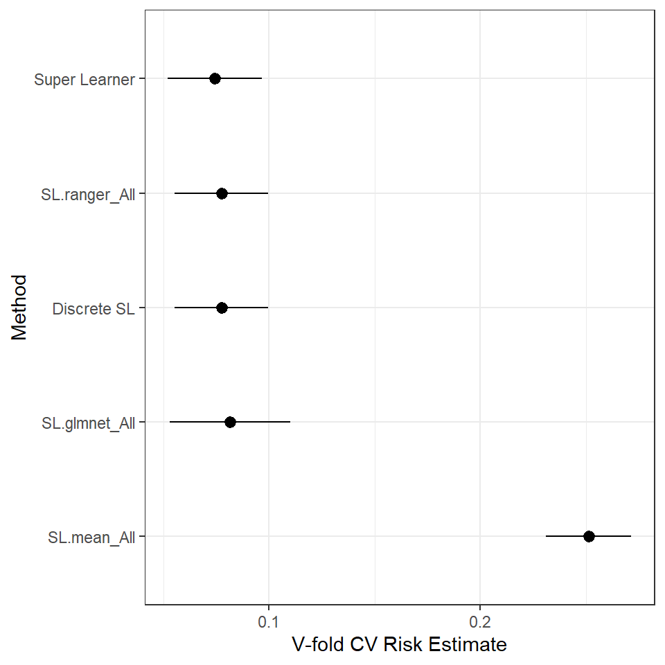

```r
# Plot the performance with 95% CIs (use a better ggplot theme).
plot(cv_sl) + theme_bw()
```

```r
# Save plot to a file.
ggsave("SuperLearner.png")
```

We see based on the outer cross-validation that SuperLearner is statistically tying with the best algorithm. Our benchmark learner “SL.mean” shows that we get a nice improvement over a naive guess based only on the mean. We could also add “SL.glm” to compare to logistic regression.